# Visual Data Science - Profile & Wrangle

Nikolaus Czernin

# Data preparation

For this project we mainly used the data contained in the data yearbooks by Statistik Austria (2019-2024) (Austria 2019-2024). They come in ZIP-files, containing folders for different data domains (education, health, immigration, etc.).

## Population data

The `bevölkerung` population data (Statistik Austria, 2024) (Austria 2019-2024), `bevoelkerung/tab_5.1.2_bevoelkerungsstandund-veraenderung_.csv`, is a single dataset that encompasses the population data per district in Vienna the early 2000s until 2024. The original file is a CSV that includes a lot of informative meta data in the same sheet, above and below the actual data table, which we prune upon loading. The variable names are renamed to enable intuitive data transformations using the dplyr library. The original data saved each year as a column, which we pivoted to create one long dataset with one district and one year per row.

## Hospitals

The `krankenhäuser` hospital data (Statistik Austria, 2019-2024) (Austria 2019-2024), `gesundheit/gesundheit_tab_6.1.2.csv`, while coming fmro the same source, only ever contains the data for the year the data set was published, so in order to get timeline data for multiple years, we had to download and wrangle each year’s data collection, laod and transform them individually and join them. This was challenging because it was no matter of copying a pasting the code, because the datasets were formatted differently over the years. Generally, wrangling steps included, again, omitting any title and metadata rows above and below the actual data table, changing the variables’ names to enable intuitive transformations, filtering out summary rows (e.g. total over all districts), formatting the numeric character columns (replacing commas with dots), and, finally, comining each year’s loaded data via `bind_rows()`.

## Doctors

The `ärztinnen` data (Statistik Austria, 2019-2024) (Austria 2019-2024), `gesundheit/gesundheit_tab_6.1.4.csv`, which contains the counts of private practice doctors per district, was also loaded via one data set per year and included the same wrangling steps as the `krankenhäuser` data.

## Geospatial data

# Exploratory Analysis

```
bevölkerung %>%
  filter(Jahr > 2019) %>%
  left_join(bezirke_wien) %>%
  ggplot(aes(x=Jahr, y=Bevölkerung, fill=Bevölkerung)) +
    geom_bar(stat="identity") +
    # geom_line() +
    # scale_fill_viridis_c(option = "plasma") +
    labs(
      title = "Entwicklung der Bevölkerung pro Wiener Gemeindebezirk von 2020 bis 2024",
      color = ""
         ) +
    theme_minimal() +
  facet_wrap(~Bezirk_Nr_Name, strip.position = "bottom") +
    scale_y_continuous(labels=label_comma()) +
    scale_fill_continuous(labels=label_comma()) +
    theme(
      axis.title = element_blank(),
      axis.text.x = element_blank(),
      panel.grid = element_blank(),
      strip.placement = "outside",
      # legend.position = "bottom",
      strip.background = element_blank()

    )
```

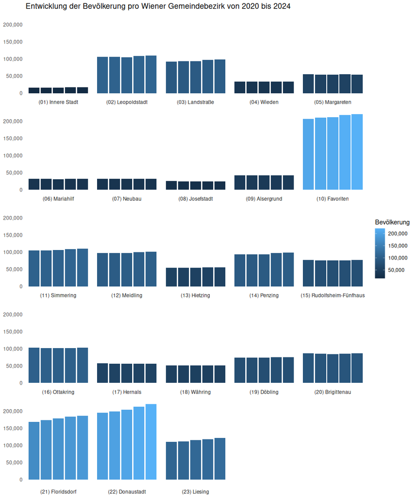

# Insights

## Insight 1: Hospitals & doctors

```
bezirke_wien
```

```
Simple feature collection with 23 features and 5 fields
Geometry type: MULTIPOLYGON
Dimension:     XY
Bounding box:  xmin: 16.17912 ymin: 48.1186 xmax: 16.57468 ymax: 48.32335
Geodetic CRS:  WGS 84
First 10 features:
   iso                  name                       geometry       Bezirk Bezirk_Nr
1  918      Wien 18.,Währing MULTIPOLYGON (((16.33922 48...      Währing        18
2  917      Wien 17.,Hernals MULTIPOLYGON (((16.3381 48....      Hernals        17
3  919      Wien 19.,Döbling MULTIPOLYGON (((16.28563 48...      Döbling        19
4  921  Wien 21.,Floridsdorf MULTIPOLYGON (((16.39537 48...  Floridsdorf        21
5  920  Wien 20.,Brigittenau MULTIPOLYGON (((16.36468 48...  Brigittenau        20
6  923      Wien 23.,Liesing MULTIPOLYGON (((16.21532 48...      Liesing        23
7  922   Wien 22.,Donaustadt MULTIPOLYGON (((16.57422 48...   Donaustadt        22
8  903   Wien  3.,Landstraße MULTIPOLYGON (((16.39268 48...   Landstraße         3
9  902 Wien  2.,Leopoldstadt MULTIPOLYGON (((16.38213 48... Leopoldstadt         2
10 905   Wien  5.,Margareten MULTIPOLYGON (((16.34696 48...   Margareten         5
      Bezirk_Nr_Name
1       (18) Währing
2       (17) Hernals
3       (19) Döbling
4   (21) Floridsdorf
5   (20) Brigittenau
6       (23) Liesing
7    (22) Donaustadt
8    (03) Landstraße
9  (02) Leopoldstadt
10   (05) Margareten
```

```
year = 2024
ärztinnen %>%
  filter(Jahr == year) %>%
  group_by(Jahr, Bezirk_Nr) %>%
  summarise(n = sum(FachärztInnen, na.rm=T)) %>%
  right_join(bezirke_wien) %>%
  mutate(n=n %>% replace_na(0)) %>%
  # print() %>%
  ggplot(aes(geometry=geometry)) +
    geom_sf(aes(fill = n), color = "white") +
    scale_fill_viridis_c(option = "plasma") +
    labs(
      title = paste("Niedergelassene Ärzt:innen pro Wiener Gemeindebezirk", year),
      fill = ""
         ) +
    theme_minimal() +
  scale_fill_gradientn(colors = c("lightblue1", "steelblue",  "blue4"),
                       values = scales::rescale(c(0, 1, 80)),) +
   theme(
      axis.text = element_blank(),
      panel.grid = element_blank(),
      aspect.ratio = .8 # Plot Seitenverhältnisse ändern
      )
```

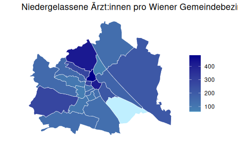

## Insight 2: Population per hospital

By joining the `bevölkerung` data set with the `geodata`, we can create another choropleth, visualizing the population for a certain year per district.

```
year = 2024
bevölkerung %>%
  filter(Jahr == year) %>%
  group_by(Jahr, Bezirk_Nr) %>%
  summarise(n = sum(`Bevölkerung`, na.rm=T)) %>%
  right_join(bezirke_wien) %>%
  mutate(n=n %>% replace_na(0)) %>%
  ggplot(aes(geometry=geometry)) +
    geom_sf(aes(fill = n), color = "white") +
    scale_fill_viridis_c(option = "plasma") +
    labs(
      title = paste("Bevölkerung pro Wiener Gemeindebezirk", year),
      fill = ""
         ) +
    theme_minimal() +
  scale_fill_gradientn(colors = c("bisque1", "sienna"),
                       labels = label_comma(),
                       values = scales::rescale(c(0, 1, 80)),) +
   theme(
      axis.text = element_blank(),
      panel.grid = element_blank(),
      aspect.ratio = .8 # Plot Seitenverhältnisse ändern
      )
```

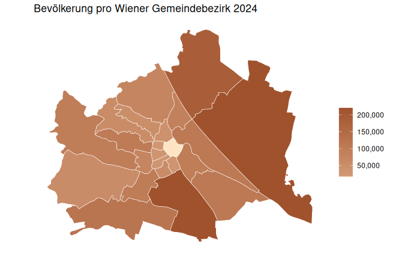

While no helpful insight can be gained here yet, we can join the resulting data set with the `krankenhäuser` and `ärztinnen` data sets to find out the number of residents per doctor stationed in a hospital and private practice doctor for each district. This shows a clearer picture of where doctors have a larger pool of possible patients.

```
# year = 2024
krankenhäuser %>%
  group_by(Jahr, Bezirk_Nr) %>%
  summarise(Ärztinnen.und.Ärzte = sum(`Ärztinnen.und.Ärzte`, na.rm=T)) %>%
  left_join(bevölkerung) %>%
  mutate(n = Bevölkerung / Ärztinnen.und.Ärzte) %>%
  filter(Jahr == year) %>%
  right_join(bezirke_wien) %>%
  mutate(n=n %>% replace_na(0)) %>%
  ggplot(aes(geometry=geometry)) +
    geom_sf(aes(fill = n), color = "white") +
    scale_fill_viridis_c(option = "plasma") +
    labs(
      title = paste("Einwohner pro stationerter Ärztin pro Wiener Gemeindebezirk", year),
      fill = ""
         ) +
    theme_minimal() +
  scale_fill_gradientn(colors = c("white", "bisque1", "sienna"),
                       labels = label_comma(),
                       values = scales::rescale(c(0, 1, 80)),) +
   theme(
      axis.text = element_blank(),
      panel.grid = element_blank(),
      aspect.ratio = .8 # Plot Seitenverhältnisse ändern
      )
```

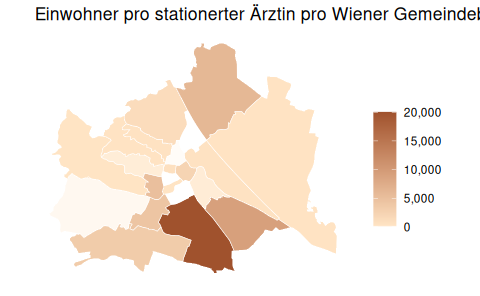

```
# year = 2024
krankenhäuser %>%
  group_by(Jahr, Bezirk_Nr) %>%
  summarise(
    Ärztinnen.und.Ärzte = sum(`Ärztinnen.und.Ärzte`, na.rm=T),
    Stationäre.Patientinnen.und.Patienten = sum(`Stationäre.Patientinnen.und.Patienten`, na.rm=T)
    ) %>%
  mutate(n = Stationäre.Patientinnen.und.Patienten / Ärztinnen.und.Ärzte) %>%
  filter(Jahr == year) %>%
  right_join(bezirke_wien) %>%
  mutate(n=n %>% replace_na(0)) %>%
  ggplot(aes(geometry=geometry)) +
    geom_sf(aes(fill = n), color = "white") +
    scale_fill_viridis_c(option = "plasma") +
    labs(
      title = paste("Stationerte Ärzt:innen pro Patient pro Wiener Gemeindebezirk", year),
      fill = ""
         ) +
    theme_minimal() +
  scale_fill_gradientn(colors = c("white", "lightblue1", "steelblue", "blue4"),
                       labels = label_comma(),
                       values = scales::rescale(c(0, 1, 80)),) +
   theme(
      axis.text = element_blank(),
      panel.grid = element_blank(),
      aspect.ratio = .8 # Plot Seitenverhältnisse ändern
      )
```

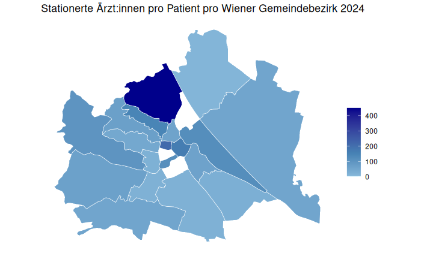

```
# year = 2024
ärztinnen %>%
  filter(Jahr == year) %>%
  left_join(bevölkerung, by=c("Bezirk_Nr", "Jahr")) %>%
  mutate(n = Bevölkerung / `FachärztInnen`) %>%
  right_join(bezirke_wien) %>%
  mutate(n=n %>% replace_na(0)) %>%
  ggplot(aes(geometry=geometry)) +
    geom_sf(aes(fill = n), color = "white") +
    scale_fill_viridis_c(option = "plasma") +
    labs(
      title = paste("Bevölkerung pro niedergelassener Fachärzt:innen\npro Wiener Gemeindebezirk", year),
      fill = ""
         ) +
    theme_minimal() +
  scale_fill_gradientn(colors = c("azure1", "lightblue1", "steelblue", "blue4"),
                       labels = label_comma(),
                       values = scales::rescale(c(0, 1, 80)),) +
   theme(
      axis.text = element_blank(),
      panel.grid = element_blank(),
      aspect.ratio = .8 # Plot Seitenverhältnisse ändern
      )
```

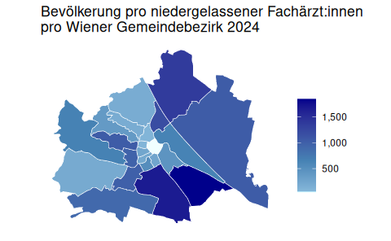

```
# year = 2024
ärztinnen %>%
  filter(Jahr == year) %>%
  left_join(bevölkerung, by=c("Bezirk_Nr", "Jahr")) %>%
  mutate(n = Bevölkerung / `Frauen.heilkunde`) %>%
  right_join(bezirke_wien) %>%
  mutate(n=n %>% replace_na(0)) %>%
  ggplot(aes(geometry=geometry)) +
    geom_sf(aes(fill = n), color = "white") +
    scale_fill_viridis_c(option = "plasma") +
    labs(
      title = paste("Bevölkerung pro niedergelassener Frauenärzt:innen pro Wiener Gemeindebezirk", year),
      fill = ""
         ) +
    theme_minimal() +
  scale_fill_gradientn(colors = c("lightblue1", "steelblue", "blue4"),
                       labels = label_comma(),
                       values = scales::rescale(c(0, 1, 80)),) +
   theme(
      axis.text = element_blank(),
      panel.grid = element_blank(),
      aspect.ratio = .8 # Plot Seitenverhältnisse ändern
      )
```

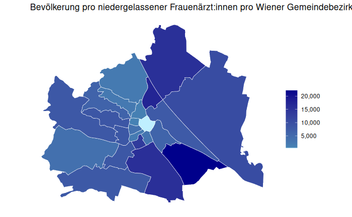

```
t <-200
krankenhäuser %>%
  mutate(Patientinnen.pro.Arzt = Stationäre.Patientinnen.und.Patienten / Ärztinnen.und.Ärzte) %>%
  group_by(Jahr, Bezirk_Nr) %>%
  summarise(n = sum(Patientinnen.pro.Arzt, na.rm=T)) %>%
  group_by(Bezirk_Nr) %>%
  filter(!any(n < t, na.rm=T)) %>%
  left_join(bezirke_wien) %>%
  ggplot(aes(x=Jahr, y=n, color=Bezirk_Nr_Name)) +
    geom_point() +
    geom_line() +
    scale_fill_viridis_c(option = "plasma") +
    labs(
      title = "Verlauf von in Krankenanstalten stationierte Patient:innen \npro Ärzt:in pro Wiener Gemeindebezirk",
      caption = "Nur die Institute mit den höchsten k Werten werden angezeigt.",
      color = ""
         ) +
    theme_minimal() +
    scale_y_continuous(labels=label_comma()) +
    # scale_fill_gradientn(colors = c("white", "lightblue1", "steelblue", "blue4"),
    #                      labels = label_comma(),
    #                      values = scales::rescale(c(0, 1, 80)),) +
    theme(
      axis.title = element_blank(),
      panel.grid = element_blank(),
      # plot.caption = element_text(hjust = 0, size = 9)
      # aspect.ratio = .8 # Plot Seitenverhältnisse ändern
    )
```

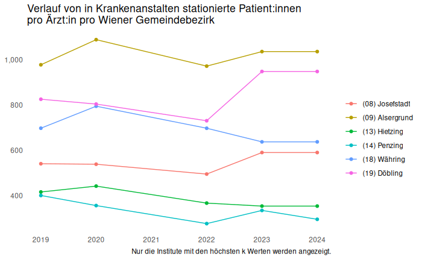

```
t <- 1000
ärztinnen %>%
  left_join(bevölkerung) %>%
  mutate(n = Bevölkerung / FachärztInnen) %>%
  right_join(bezirke_wien) %>%
  mutate(n=n %>% replace_na(0)) %>%
  group_by(Bezirk_Nr) %>%
  filter(!any(n < t, na.rm=T)) %>%
  ggplot(aes(x=Jahr, y=n, color=Bezirk_Nr_Name)) +
    geom_point() +
    geom_line() +
    scale_fill_viridis_c(option = "plasma") +
    labs(
      title = "Verlauf von Bevölkerung \npro niedergelassener Fachärzt:in pro Wiener Gemeindebezirk",
      caption = "Nur die Institute mit den höchsten k Werten werden angezeigt.",
      color = ""
         ) +
    theme_minimal() +
    scale_y_continuous(labels=label_comma()) +
    # scale_fill_gradientn(colors = c("white", "lightblue1", "steelblue", "blue4"),
    #                      labels = label_comma(),
    #                      values = scales::rescale(c(0, 1, 80)),) +
    theme(
      axis.title = element_blank(),
      panel.grid = element_blank(),
      # plot.caption = element_text(hjust = 0, size = 9)
      # aspect.ratio = .8 # Plot Seitenverhältnisse ändern
    )
```

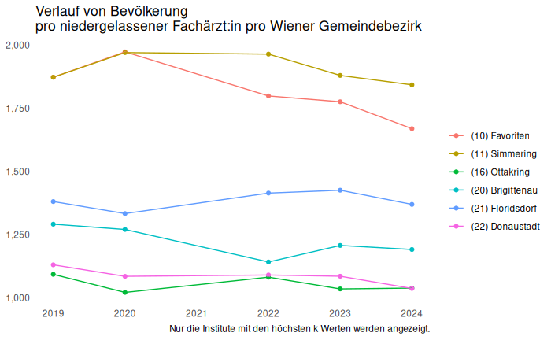

## Insight 3: Scarcity of medical specialties

The previous insights focused on all kinds of private practitioners, however, some types of specialties are more common and some more scarce than others.

By grouping the `ärztinnen` data per year and summing the doctor counts, we get the number of specialized practitioners per year and can investigate, which specialists are more scarce than others. By, again, joining it with the `bevölkerung` data, we can get the relative population per specialist for each year.

```
bevölkerung_gesamt <- bevölkerung %>%
  group_by(Jahr) %>%
  summarise(Bevölkerung = sum(Bevölkerung, na.rm=T))

ärztinnen %>%
  select(-FachärztInnen) %>%
  pivot_longer(-c("Bezirk", "Bezirk_Nr", "Jahr"), names_to = "Fachrichtung", values_to = "n") %>%
  group_by(Fachrichtung, Jahr) %>%
  summarise(n = sum(n, na.rm=T)) %>%
  left_join(bevölkerung_gesamt) %>%
  mutate(n_rel = Bevölkerung / n) %>%
  ggplot(aes(x=Jahr, y=n_rel, color=Fachrichtung)) +
    geom_point() +
    geom_line() +
    scale_fill_viridis_c(option = "plasma") +
    labs(
      title = "Verlauf Einwohnerzahl je Ärzt:innen \npro medizinischer Fachrichtung",
      color = ""
         ) +
    theme_minimal() +
    # ylim(0, 8200) +
    scale_y_continuous(labels=label_comma()) +
    theme(
      axis.title = element_blank(),
      panel.grid = element_blank(),
    )
```

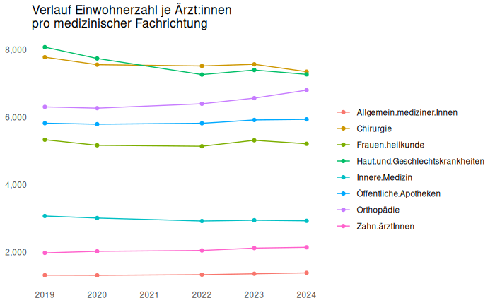

The line plot above shows that general practitioners are by far the most common, followed by dentists and internal specialists. The most scarce are surgeons and dermatologists, followed by orthopedists and obstetricians. Pharmacies are shown up there in the top scarce groups too, though they serve a different purpose altogether.

```
krankenhäuser %>%
  transmute(
    Bezirk_Nr, Krankenanstalt, Jahr,
    `Patient:innen pro Ärzt:in` = (Stationäre.Patientinnen.und.Patienten / Ärztinnen.und.Ärzte) %>% round(),
    `Patient:innen pro Nicht-Ärzt:in` = (Stationäre.Patientinnen.und.Patienten / Personen.in.nicht.ärztlichen.Gesundheitsberufen) %>% round(),
    `Patient:innen pro Bett` = (Stationäre.Patientinnen.und.Patienten / Systematisierte.Betten) %>% round(),
    ) %>%
  arrange(desc(`Patient:innen pro Ärzt:in`)) %>%
  head(20) %>%
  knitr::kable()
```

| Bezirk_Nr | Krankenanstalt | Jahr | Patient:innen pro Ärzt:in | Patient:innen pro Nicht-Ärzt:in | Patient:innen pro Bett |
| --- | --- | --- | --- | --- | --- |
| 18 | Privatklinik WÃ¤hring | 2020 | 616 | 123 | 123 |
| 8 | Privatklinik Confraternität | 2024 | 568 | 77 | 71 |
| 8 | Privatklinik Confraternität | 2023 | 568 | 77 | 71 |
| 18 | Privatklinik Währing | 2022 | 563 | 113 | 113 |
| 9 | Wiener Privatklinik | 2020 | 561 | 46 | 58 |
| 19 | Rudolfinerhaus Privatklinik | 2024 | 545 | 42 | 70 |
| 19 | Rudolfinerhaus Privatklinik | 2023 | 545 | 42 | 70 |
| 9 | Wiener Privatklinik | 2024 | 533 | 52 | 55 |
| 9 | Wiener Privatklinik | 2023 | 533 | 52 | 55 |
| 9 | Wiener Privatklinik | 2022 | 514 | 42 | 50 |
| 18 | Privatklinik Währing | 2024 | 504 | 168 | 101 |
| 18 | Privatklinik Währing | 2023 | 504 | 168 | 101 |
| 9 | Wiener Privatklinik | 2019 | 503 | 46 | 59 |
| 19 | Privatklinik Döbling | 2019 | 488 | 57 | 95 |
| 8 | Privatklinik Confraternität | 2019 | 487 | 68 | 86 |
| 8 | Privatklinik ConfraternitÃ¤t | 2020 | 486 | 67 | 81 |
| 18 | Privatklinik Währing | 2019 | 478 | 101 | 96 |
| 8 | Privatklinik Confraternität | 2022 | 467 | 53 | 73 |
| 19 | Privatklinik DÃ¶bling | 2020 | 461 | 62 | 98 |
| 19 | Privatklinik Döbling | 2024 | 403 | 58 | 101 |

```
NA
```

# References

Austria, Statistik. 2019-2024. “Statistisches Jahrbuch Der Stadt Wien.” Statistik Austria. https://www.data.gv.at/katalog/datasets/a6b357c5-03c9-4743-9d3d-b6624294e7b9.

Perlot, Flooh. 2021. “GeoJSON/TopoJSON Austria (2016–2021).” GitHub. https://github.com/ginseng666/GeoJSON-TopoJSON-Austria.